# Chapter C5

# 圧縮、剪断、曲げおよび複合応力下における平板の座屈強度

## C5.1 はじめに

第A18章第2部では、様々な端部境界条件を持つ、圧縮を受ける平板の座屈方程式を決定する問題への理論的アプローチを学びました。剪断や曲げなどの他の荷重系に対しても同様の理論的アプローチがなされており、平板の座屈方程式は長年にわたり利用可能となっています。本章では、これらの式を要約し、外板およびプレート構造の設計に実用的に使用できる設計チャートを提供します。本章の材料の大部分は、GerardおよびBeckerによるNACA Technical Note 3781-Part I「平板の座屈」（文献1）から引用されています。この報告書は、1957年以前に発表された実質的にすべての重要な理論的および実験的研究を網羅的に調査し要約したものです。この報告書は、特に構造設計エンジニアにとって有用です。

## C5.2 圧縮を受ける平板の弾性座屈強度の式

第A18章より、圧縮を受ける平板の弾性不安定性に対する式は以下の通りです。

$$\sigma_{cr} = \frac{\pi^2 k_C E}{12 (1 -
u_e^2)} \left(\frac{t}{b}\right)^2 \quad \text{--- (C5.1)}$$

ここで、

- $k_C$ = 端部の境界条件および板のアスペクト比（ $a/b$ ）に依存する座屈係数
- $E$ = 弾性係数
- $u_e$ = 弾性ポアソン比
- $b$ = プレートの短辺寸法または載荷辺
- $t$ = 板厚

## C5.3 座屈係数 $k_C$

Fig. C5.1は、非載荷辺の境界条件が自由から拘束へと変化するときの、座屈形状の変化を示しています。

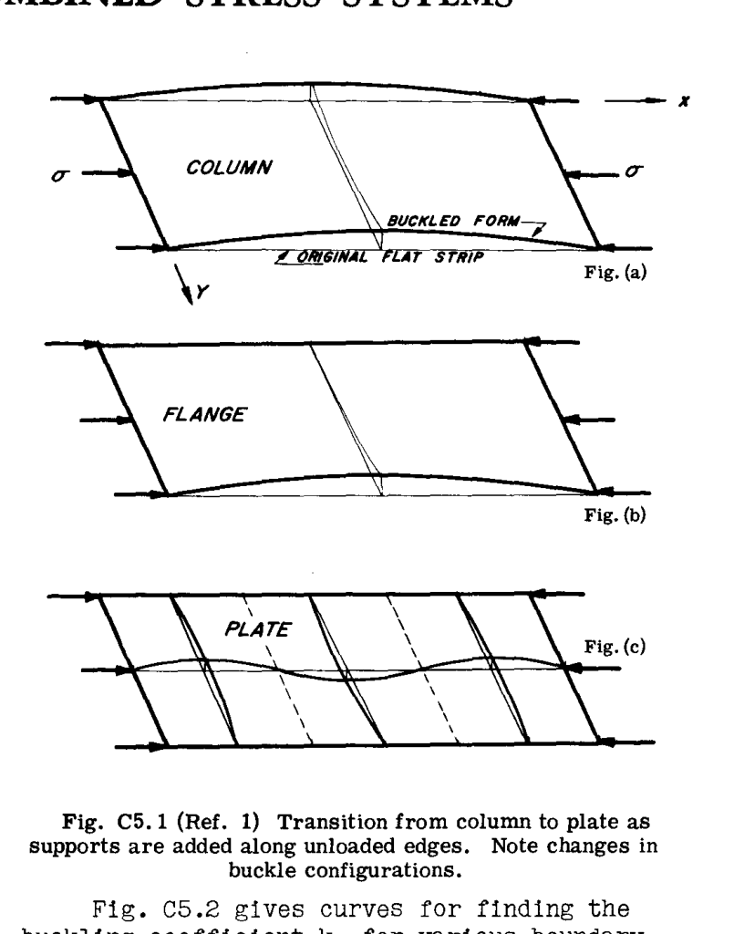

Fig. C5.1

Fig. (a)では、両側が自由であるため、板は柱として動作します。Fig. (b)では、一方が拘束され、他方が自由であり、このような拘束された板はフランジと呼ばれます。Fig. (c)では、両側が拘束されており、この拘束された要素はプレートと呼ばれます。

Fig. C5.2は、様々な境界条件または端部条件、および板の $a/b$ 比に対する座屈係数 $k_C$ を求めるための曲線を示しています。

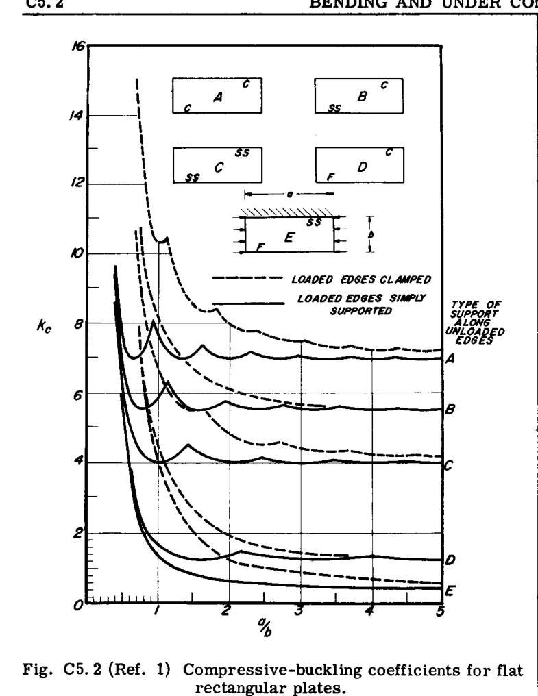

Fig. C5.2

端部の文字Cは、クランプ（回転固定）されていることを意味します。文字Fは自由端、SSは単純支持またはヒンジを意味します。Fig. C5.3は、板パネルの側面に沿った様々な拘束度（ $\epsilon$ ）に対する $k_C$ の曲線を示しています。ここで、 $\epsilon$ はプレートの端部補強材の回転剛性とプレートの回転剛性との比です。

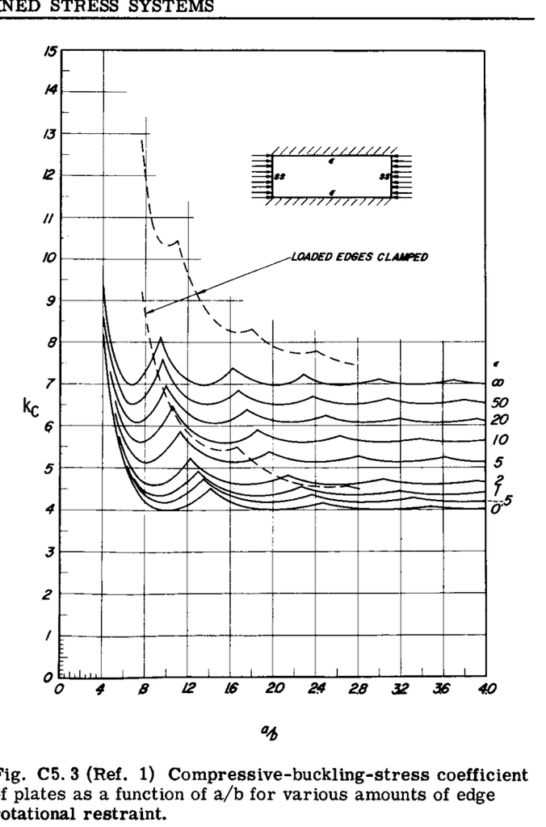

Fig. C5.3

Fig. C5.4は、一辺が自由で、もう一辺が様々な拘束度を持つフランジに対する $k_C$ の曲線を示しています。

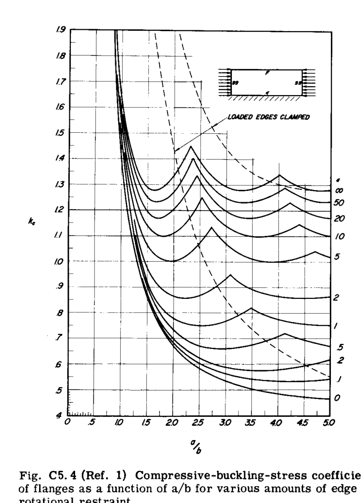

Fig. C5.4

Fig. C5.5は、圧縮応力が板の長さにわたって線形に変化する場合（典型的な例として、通常の飛行状態下にある片持ち翼の上面の外板パネルなど）を示しています。

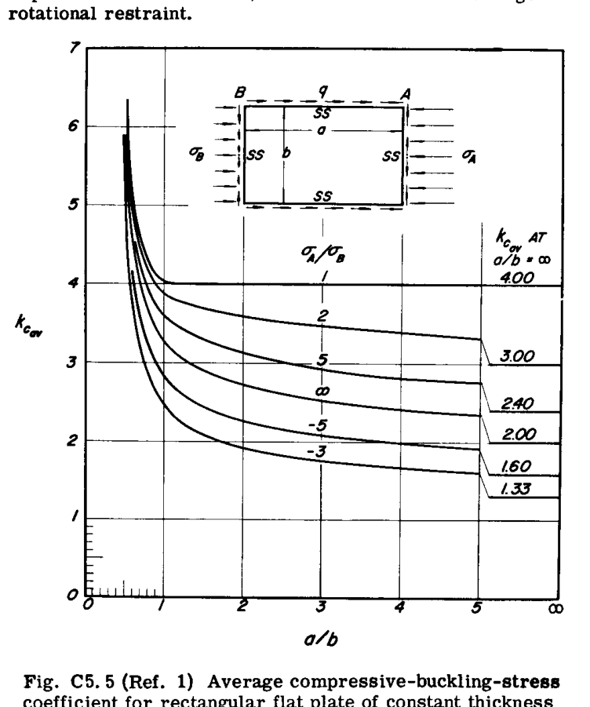

Fig. C5.5

Fig. C5.6は、2つの極端な端部補強材、すなわちねじり剛性が弱いゼット型補強材と、閉断面で比較的ねじり剛性が強いハット型断面を持つ、長い板パネルの $k_C$ 係数を示しています。

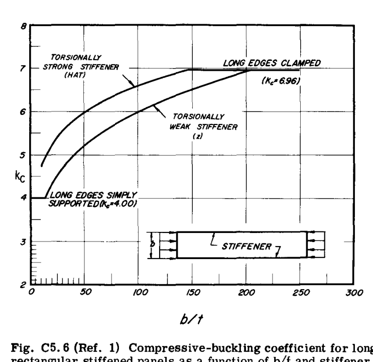

Fig. C5.6

Fig. C5.6aは、二等辺三角形のプレートに対する圧縮座屈係数 $k_C$ を示しています。

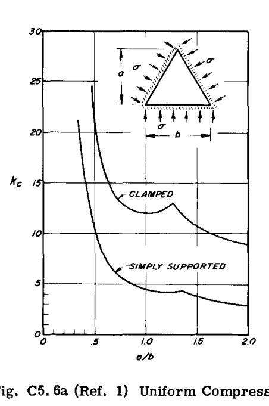

Fig. C5.6a

### 例題

$a = 10$ インチ、 $b = 5$ インチ、厚さ $t = 0.04$ インチで、すべての辺が単純支持されている板パネルの圧縮座屈応力を求めよ。材料は2024-T3アルミニウム合金とする。

**解答**:

$E = 10,700,000$ psi、 $u_e = 0.3$

$a/b = 10/5 = 2$

境界条件はFig. C5.2のケース(c)に対応する。したがって、 $a/b = 2$ に対する曲線(c)を用いて、以下を読み取る。

$k_C = 4.0$

式(C5.1)に代入すると、

$$\sigma_{cr} = \frac{\pi^2 \times 4.0 \times 10,700,000}{12 (1 - 0.3^2)}
\left(\frac{0.04}{5}\right)^2 = 2480 \text{ psi}$$

この応力は材料の比例限度応力を下回っているため、式(C5.1)が適用され、塑性補正は不要である。

## C5.4 圧縮を受ける平板の非弾性座屈強度式

座屈または不安定性が非弾性または塑性応力領域の応力で発生する場合、 $E$ と $u$ は弾性座屈の場合と同じではないため、塑性補正係数が必要となり、式(C5.1)は以下のように書き換えられます。

$$\sigma_{cr} = \frac{\eta \pi^2 k_C E}{12 (1 -
u_e^2)} \left(\frac{t}{b}\right)^2 \quad \text{--- (C5.2)}$$

ここで、 $\eta$ は塑性減少係数であり、 $\sigma_{cr \text{ plastic}} / \sigma_{cr \text{ elastic}}$ に等しくなります。

$k_C$ と $u_e$ の値は常に弾性値です。これは、係数 $\eta$ に非弾性挙動から生じるそれらの項のすべての変化が含まれているためです。

いわゆる塑性補正係数の値に関して、膨大な量の理論的および実験的研究が行われてきました。設計エンジニアによって最初に使用された値は、 $\eta = E_t/E$ または $\eta = E_{sec}/E$ であったと考えられます。 $\eta$ の表現が何であれ、それは非弾性応力範囲における材料の剛性の尺度を含まなければならず、塑性範囲における応力-歪み関係は非線形であるため、塑性補正係数を得るためには応力-歪み曲線に頼る必要があります。この複雑さは、3つの単純なパラメータを含む応力-歪み曲線に対するRambergおよびOsgoodの式を使用することで大幅に簡素化されます（Ramberg-Osgoodの式に関する情報については、第B1章を参照してください）。したがって、Ramberg-Osgoodのパラメータ（文献1）を使用して、弾性および非弾性の両方の座屈または不安定性に対する様々な境界条件を持つ平板パネルの圧縮座屈応力を求めるためのFig. C5.7およびFig. C5.8が提示されています。

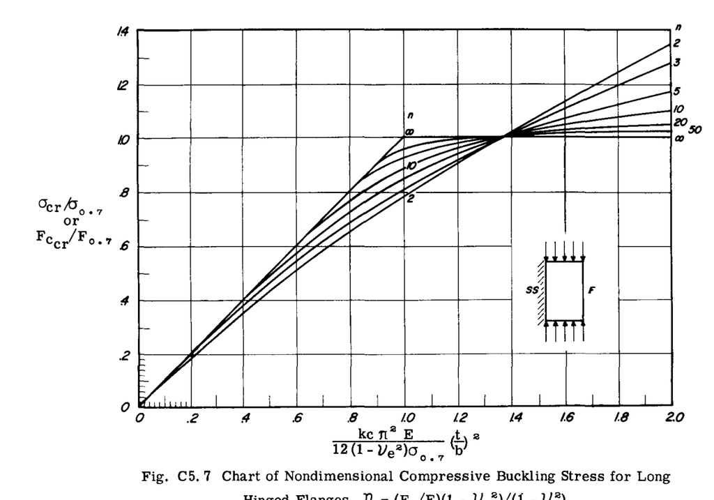

Fig. C5.7

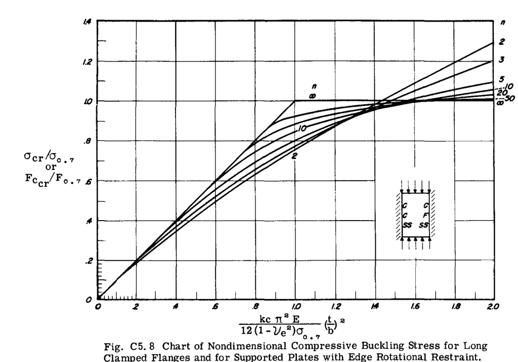

Fig. C5.8

## C5.5 Fig. C5.7 および Fig. C5.8 の曲線の使用を説明する簡単な問題

図は $3 \times 9$ インチの板パネルを示しています。側面は単純支持されています。材料は2024-T3アルミニウム合金です。厚さは $0.094$ インチです。 $E = 10,700,000$ psi、 $u_e = 0.3$ 。座屈応力 $\sigma_{cr}$ を求めよ。

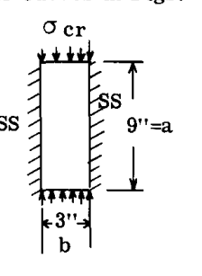

The sketch

**解答**:

問題の境界条件をカバーしているため、Fig. C5.8を使用します。底面スケールのパラメータは以下の通りです。

$$\frac{k_C \pi^2 E}{12 (1 -
u_e^2) \sigma_{0.7}} \left(\frac{t}{b}\right)^2 \quad \text{--- (A)}$$

$a/b = 9/3 = 3$ に対して、Fig. C5.2の曲線(c)から $k_C = 4.0$ を得ます。

Fig. C5.8を使用するには、Ramberg-Osgoodパラメータである $\sigma_{0.7}$ と $n$ を使用する必要があります。第B1章のTable B1.1を参照すると、2024-T3アルミニウム合金の場合、 $\sigma_{0.7} = 39,000$ psi、形状係数 $n = 11.5$ であることがわかります。

(A)に代入すると：

$$\frac{4.0 \pi^2 \times 10,700,000}{12 (1 - 0.3^2) \times 39,000}
\left(\frac{0.094}{3}\right)^2 = 0.98$$

Fig. C5.8から、底面スケールで $0.98$ 、および $n = 11.5$ の曲線を使用すると、左側のスケールから以下が読み取れます。

$$\sigma_{cr} / \sigma_{0.7} = 0.84$$

したがって、

$$\sigma_{cr} = 39,000 \times 0.84 = 32,800 \text{ psi}$$

もし塑性効果を無視した場合、式(C5.2)を $\eta = 1.0$ として使用し、以下のようになります。

この例で使用した板厚 $0.094$ は比較的大きいです。板厚を $0.051$ インチに変更した場合、曲線の読み取り精度の範囲内では実質的に補正は不要となり、座屈応力 $\sigma_{cr}$ は $11,200$ psi と計算されます。これは比例限度応力を下回っているため、塑性補正は不要です。

## C5.6 アルクラッド減少係数

アルミニウム合金板は、実質的に純アルミニウムの薄い被覆を伴って入手可能であり、航空機構造で広く使用されています。このような材料は、アルクラッドまたは合わせアルミニウム合金と呼ばれます。この合わせ材の機械的強度の特性は、芯材（コア）の特性よりもかなり低いです。被覆（クラッド）はアルクラッド板の極外層に配置されているため、座屈が発生したときに歪みが最大値に達する場所に位置しています。Fig. C5.9はアルクラッド板の構成を示しており、Fig. C5.10は被覆、芯材、およびアルクラッドの組み合わせに対する応力-歪み曲線を示しています。

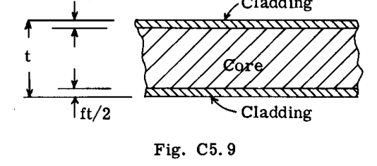

Fig. C5.9

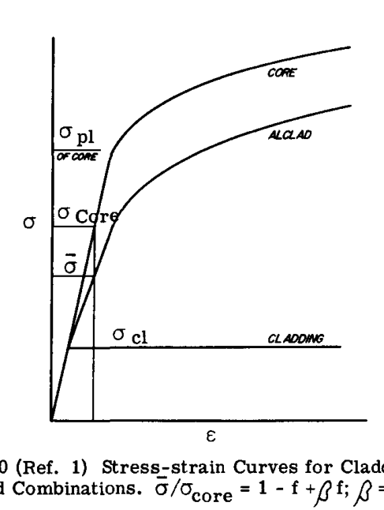

Fig. C5.10

文献1は、Table C5.1に要約されているように、簡略化されたクラッド減少係数を提供しています。したがって、アルクラッド板の座屈応力は、前述の2つの例題で示したように、通常これらの材料に対してリストされている主要な強度特性に対して決定されます。得られた $\sigma_{cr}$ は、Table C5.1からの $\bar{\eta}$ の値を使用して、式(C5.3)を用いて減少されます。

$$\bar{\sigma}_{cr} = \bar{\eta} \sigma_{cr} \quad \text{--- (C5.3)}$$

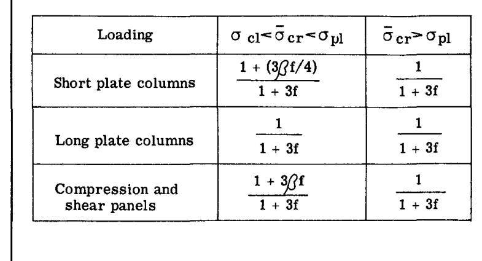

Table C5.1

## C5.7 剪断荷重を受ける平板の座屈

ここで、 $b$ は、すべての辺が剪断力を伝えるため、常にプレートの短い方の寸法です。 $k_S$ は剪断座屈係数であり、Fig. C5.11に単純支持端および固定端についてプレートのアスペクト比 $a/b$ の関数としてプロットされています。

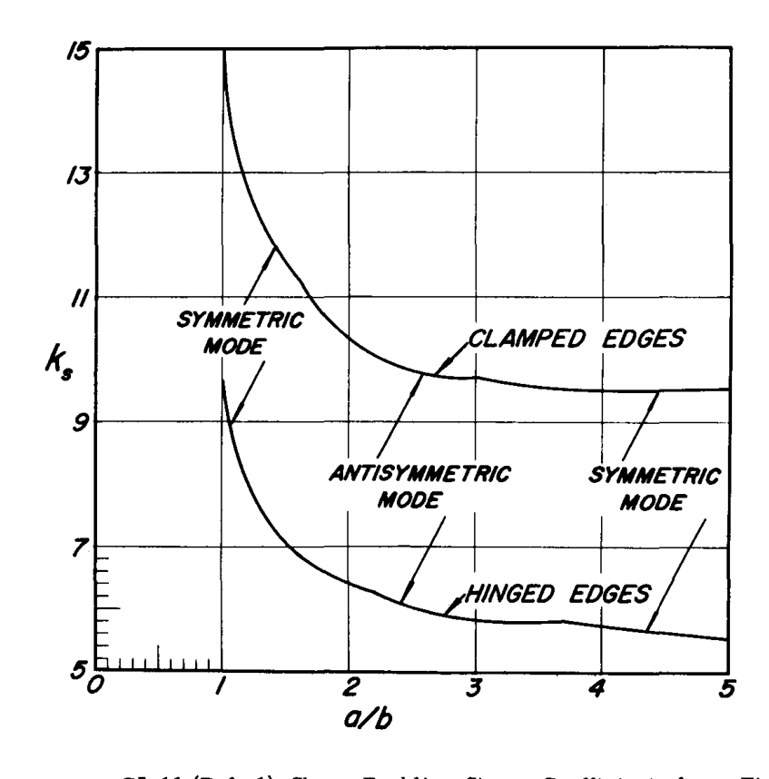

Fig. C5.11

座屈が比例限度以上の応力で発生する場合、塑性補正を含める必要があり、式(C5.4)は以下のようになります。

$$\tau_{cr} = \frac{\eta_s \pi^2 k_S E}{12 (1 -
u_e^2)} \left(\frac{t}{b}\right)^2 \quad \text{--- (C5.5)}$$

試験結果は、 $\eta_s = G_s/G$ （ここで $G$ は剪断弾性係数、 $G_s$ は材料の剪断応力-歪み図から得られる剪断割線弾性係数）とすると、式(C5.5)の結果とよく一致します。

純剪断を受ける長い矩形板は、板の端部と45度の面で内部引張応力と圧縮応力を生じ、これらの圧縮応力により、長いパネルはFig. C5.12に示すように板の端部に対して角度を持ったパターンで座屈します。また、座屈パターンは $1.25b$ の半波長を持ちます。

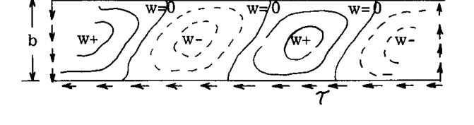

Fig. C5.12

Fig. C5.13は、様々な端部回転拘束を持つパネルの無次元剪断座屈応力のチャートです。このチャートは、剪断座屈応力を求めるためにチャートを使用する前に、材料の $\sigma_{0.7}$ と $n$ の値を知っておく必要があるという点で、Fig. C5.7およびFig. C5.8のチャートと似ています。

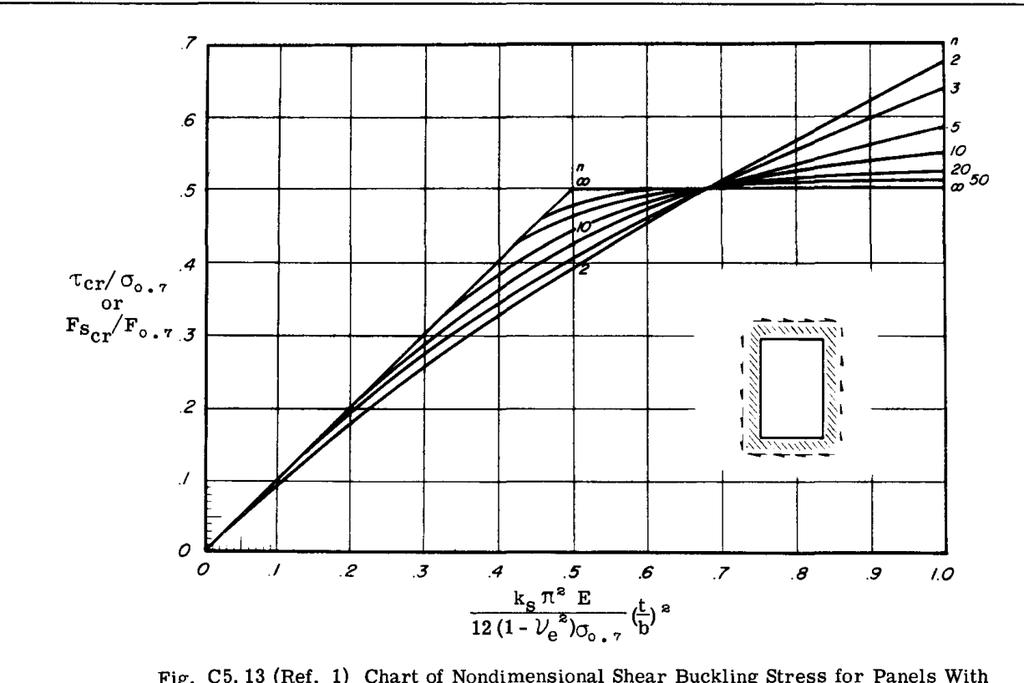

Fig. C5.13

## C5.8 曲げ荷重を受ける平板の座屈

曲げを受ける平板の曲げ不安定性に対する式は、座屈係数 $k_b$ が $k_C$ や $k_S$ と異なる点を除いて、圧縮や剪断の場合と同じです。曲げを受けるプレートが座屈する場合、単純支持された端部を持つ長いプレートでは $2/3 b$ に等しい比較的短い波長の座屈を伴います（Fig. C5.14を参照）。したがって、より小さい座屈パターンにより、座屈係数 $k_b$ は $k_C$ や $k_S$ よりも大きくなります。

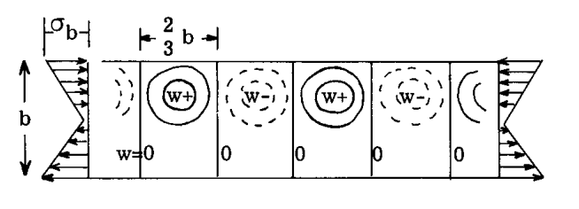

Fig. C5.14

曲げ弾性座屈の式は以下の通りです。

$$\sigma_{cr} = \frac{\pi^2 k_b E}{12 (1 -
u_e^2)} \left(\frac{t}{b}\right)^2 \quad \text{--- (C5.6)}$$

曲げ非弾性座屈の場合、

$$\sigma_{cr} = \frac{\eta_b \pi^2 k_b E}{12 (1 -
u_e^2)} \left(\frac{t}{b}\right)^2 \quad \text{--- (C5.7)}$$

ここで、 $k_b$ は座屈係数であり、様々な $a/b$ 比および回転に対する端部拘束 $\epsilon$ についてFig. C5.15から得られます。 $a/b$ 比において、載荷辺は ( $b$ ) です。

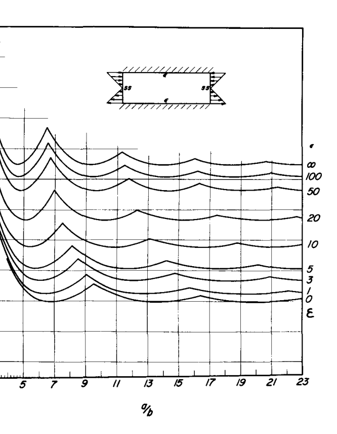

Fig. C5.15

塑性減少係数は、単純支持端を用いてFig. C5.8から得ることができます。

# 複合荷重を受ける平板の座屈

薄い板の使用を伴う実用的な設計ケースは、通常、複合荷重系を伴うため、複合応力下における平板の座屈強度の計算が必要です。使用されるアプローチは、相互作用公式または曲線の使用を伴います（相互作用公式の説明については、第C1章、第C1.15節を参照してください）。

## C5.9 曲げと縦圧縮の複合荷重

曲げと縦圧縮の複合荷重に対して広く使用されてきた相互作用公式は、以下の通りです。

$$R_b^{1.75} + R_C = 1.0 \quad \text{--- (C5.8)}$$

この式は元々文献2で提示されたものであり、この式をプロットした相互作用曲線は、多くの航空宇宙企業の構造マニュアルに見られます。

Fig. C5.15は式(C5.8)をプロットしたものです。また、様々な安全余裕値に対する曲線も示しています。

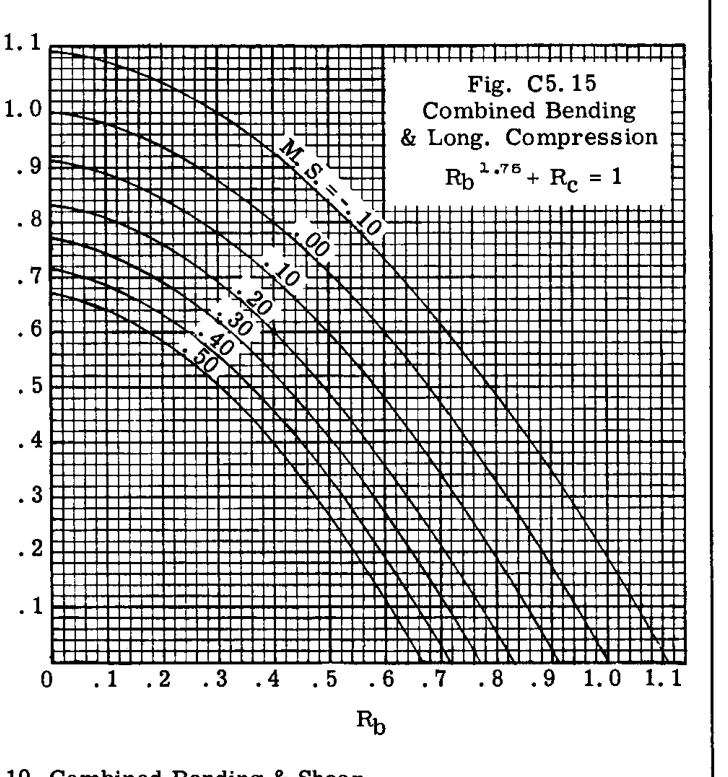

Fig. C5.15

## C5.10 曲げと剪断の複合荷重

この複合荷重に対する相互作用公式（文献1＆2）は、以下の通りです。

$$R_b^2 + R_S^2 = 1 \quad \text{--- (C5.9)}$$

安全余裕（M.S.）の式は、以下の通りです。

$$\text{M.S.} = \frac{1}{\sqrt{R_b^2 + R_S^2}} - 1 \quad \text{---
(C5.10)}$$

Fig. C5.16は式(C5.9)をプロットしたものです。様々な M.S. 値を示す曲線も示されています。 $R_S$ はねじり剪断応力による応力比であり、 $R_{st}$ は横剪断応力または曲げ剪断応力による応力比です。

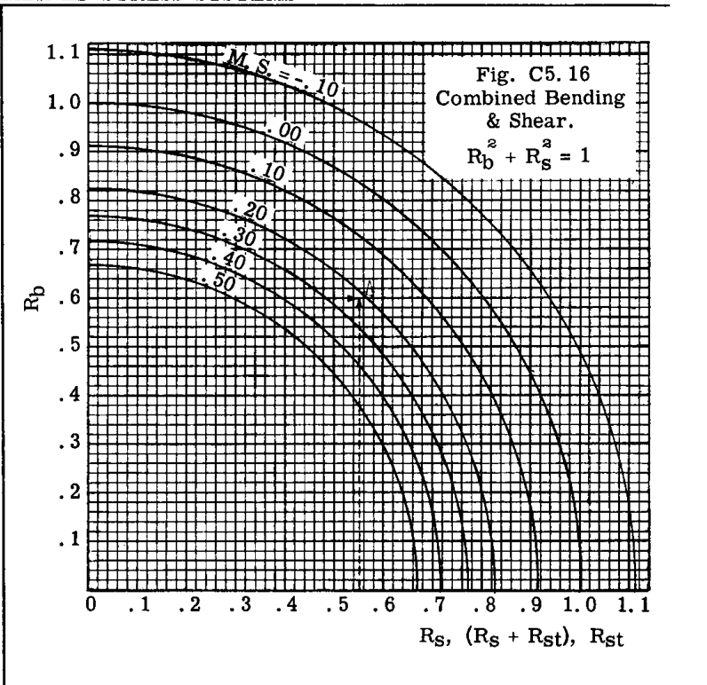

Fig. C5.16

## C5.11 剪断と縦方向直応力の複合荷重（引張または圧縮）

相互作用公式は以下の通りです（文献3, 4）。

$$R_L + R_S^2 = 1.0 \quad \text{--- (C5.11)}$$

$$\text{M.S.} = \frac{2}{(R_L + \sqrt{R_L^2 + 4 R_S^2})} - 1 \quad
\text{--- (C5.12)}$$

Fig. C5.17は式(C5.11)をプロットしたものです。直応力が引張である場合、許容圧縮応力を使用して負の圧縮として図に含まれます。

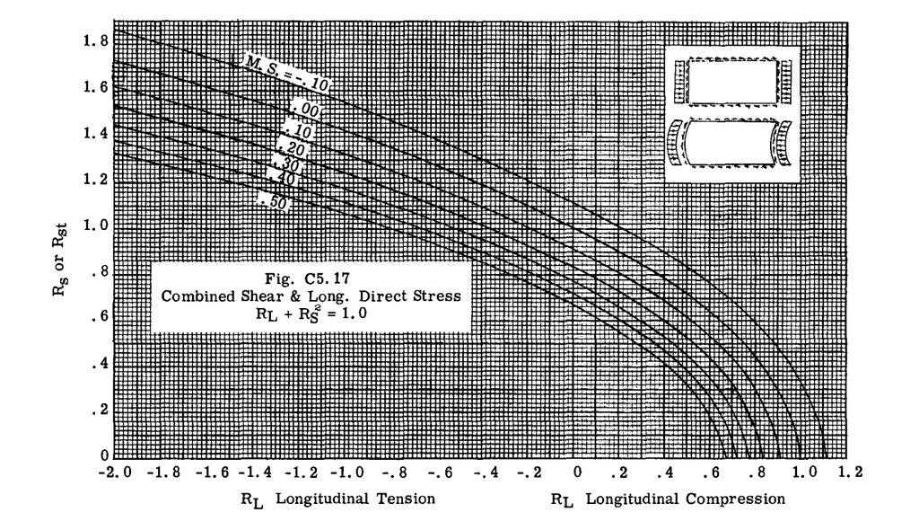

Fig. C5.17

## C5.12 圧縮、曲げ、剪断の複合荷重

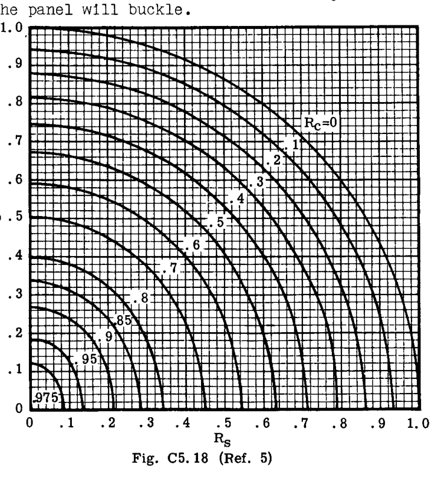

Fig. C5.18

弾性座屈した平板パネルの安全余裕は、Fig. C5.19から決定できます。破線は、 $R_C = 0.161$ , $R_S = 0.23$ , $R_b = 0.38$ である典型的な適用例を示しています。まず、 $R_S$ と $R_b$ の特定の値に対して点1が決定されます。原点0から点1を通り、関連する $R_C/R_S$ 曲線と点2で交差する破線の対角線は、所望の安全余裕計算のための許容剪断応力および曲げ応力を与えます。（ $R_C$ が $R_S$ 未満の場合は図の右半分を使用し、それ以外の場合は左半分を使用することに注意してください）。

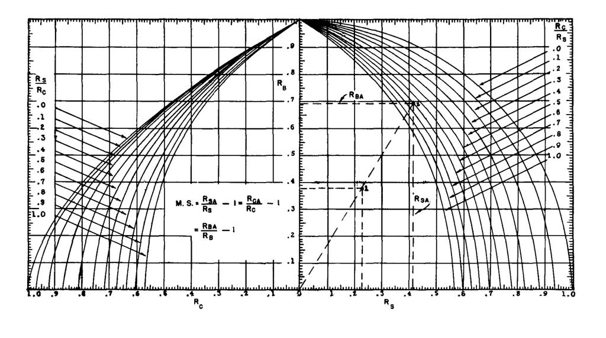

Fig. C5.19

## C5.13 例題

一般に、補強された板パネルで構成される構造部材は、板パネルの座屈が発生したときに破壊することはありません。これは、補強ユニットが通常、破壊する前により多くの荷重を支持し続けることができるためです。しかし、板パネルの初期座屈が特定の設計仕様を満たすことを要求する多くの設計状況があります。例えば、低翼旅客機の上面外板は、通常の日常的な飛行で発生する突風による加速度下で座屈してはならず、それによって乗客が飛行中に翼外板の座屈を観察するのを防ぎます。別の例としては、航空機が満載状態で地上にあるときに胴体外板パネルの座屈が発生してはならないというものであり、これにより一般の人が胴体外板の座屈を観察するのを防ぎます。多くの航空機では、燃料タンクが翼または胴体と一体化されて作られているため、漏洩の発生を防ぐために、燃料タンクを境界とする板パネルの座屈が飛行および着陸状態で発生しないように設計することが最善です。場合によっては、空気力学的または剛性の要件により、板パネルの座屈を許容しないように指示されることがあります。特定の荷重要件下で座屈が発生しないことを保証するために、板パネルの境界拘束を選択または計算する際に保守的であることが推奨されます。

### 問題1

Fig. C5.20は、外板、補強材、およびリブで構成される片持ち翼の一部を示しています。問題は、マーキングされた外板パネル(A)、(B)、および(C)が、与えられた様々な荷重ケースの下で座屈するかどうかを決定することです。板の材料は2024-T3アルミニウム合金です。

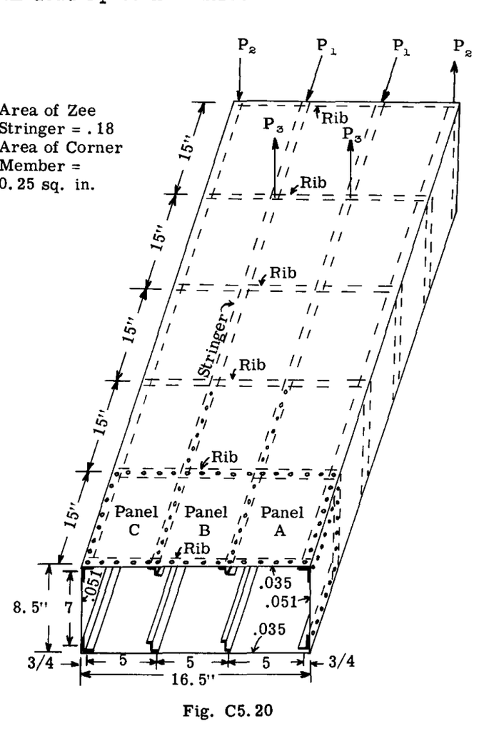

Fig. C5.20

### 荷重ケース1

$P_1 = 700$ lb.、 $P_2 = 0$ 、 $P_3 = 0$

$P_1$ の荷重のみが作用する場合、1セルの補強された片持ち梁は、 $2 \times 700 = 1400$ lb. の圧縮軸荷重を受けます。 $P_1$ 荷重は断面の図心を通って作用していないため、 $1400 \times 3.7 = 5170$ in. lb. = $M_x$ に等しい曲げモーメントが x-x 軸まわりに発生します。ここで、3.7 は荷重 $P_1$ から x-x 軸までの距離です。

外板の厚さ、補強材の面積、およびすべての必要な寸法は Fig. C5.20 に示されています。すべての外板と補強材を含む梁断面の総断面積は $3.73$ sq. in. です。x-x 図心軸まわりの慣性モーメントは $49.30$ in. $^4$ と計算されます。

梁の断面は対称であるため、上面パネルA、B、およびCは、 $P_1$ 荷重系の下で同じ応力を受けます。

荷重 $P_1$ を梁断面の図心に移動させることによる圧縮応力は、

$${f_c} = 2P_1 / \text{area} = 1400/3.73 = 375 \text{ psi}$$

$5170$ in. lbs. の一定の曲げモーメントによる圧縮応力は、

$${f_c} = M_x Z / I_x = 5170 \times 4.233 / 49.30 = 444 \text{ psi}$$

総 $f_c = 375 + 444 = 819$ psi。

外板パネルは、Fig. (a)に示すように圧縮を受けます。縦方向の補強材とリブフランジによって与えられる境界端部条件は、保守的に単純支持と仮定されます（ $F_{Ccr}$ は $\sigma_{cr}$ と同じです）。

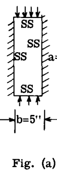

Fig. (a)

$$F_{Ccr} = \frac{\pi^2 k_C E}{12 (1 -
u_e^2)} \left(\frac{t}{b}\right)^2$$

（式 C5.1 を参照）

外板パネルの $a/b = 15/5 = 3$

Fig. C5.2からケースCに対して、 $k_C = 4.0$ を読み取ります。

$$F_{Ccr} = \frac{\pi^2 \times 4.0 \times 10,700,000}{12 (1 - 0.3^2)}
\left(\frac{0.035}{5}\right)^2 = 1900 \text{ psi}$$

座屈応力 $F_{Ccr}$ は作用応力 $f_c$ よりも大きいため、パネルは座屈しません。

$$\text{M.S.} = (F_{Ccr}/f_c) - 1 = (1900/819) - 1 = 1.32$$

### 荷重ケース2

$P_1 = 700$ lb.、 $P_2 = 500$ 、 $P_3 = 0$

逆方向に作用する2つの荷重 $P_2$ は、梁構造に $500 \times 16.5 = 8250$ in. lb. の偶力またはねじりモーメントを発生させます。これは、ケース1の荷重の圧縮応力系に純剪断応力系を追加したことを意味します。

上面パネルA、B、Cにおける剪断応力は、

$$f_s = T/2At = 8250 / (2 \times 138 \times 0.035) = 854 \text{ psi}$$

（ここで $A$ はセル囲まれた面積です）

剪断座屈応力は、

$$F_{Scr} = \frac{\pi^2 k_S E}{12 (1 -
u_e^2)} \left(\frac{t}{b}\right)^2 \quad \text{--- (式 C5.4 を参照)}$$

$a/b = 15/5 = 3$ 。Fig. C5.11から、ヒンジ端または単純支持端に対して、 $k_S = 5.8$ を読み取ります。

$$F_{Scr} = \frac{\pi^2 \times 5.8 \times 10,700,000}{12 (1 - 0.3^2)}
\left(\frac{0.035}{5}\right)^2 = 2760 \text{ psi}$$

$$R_C = f_c/F_{Ccr} = 819/1900 = 0.431$$

$$R_S = f_s/F_{Scr} = 854/2760 = 0.309$$

$${R_C} + R_S^2 = 0.431 + 0.309^2 = 0.526$$

結果は1.0未満であるため、座屈は発生しません。

$$\text{The M.S.} = \frac{2}{R_C + \sqrt{R_C^2 + 4 R_S^2}} - 1 =
\frac{2}{0.431 + \sqrt{0.431^2 + 4 \times 0.309^2}} - 1 = 0.69$$

### 荷重ケース3

$P_1 = 700$ 、 $P_2 = 500$ 、 $P_3 = 100$ lb.

2つの荷重 $P_3$ は、梁に曲げおよびたわみ剪断を発生させます。曲げモーメントがパネルモーメントにわたって一定ではないため、曲げモーメントは3つの外板パネルに異なる端部圧縮応力を発生させます。簡略化するために、パネル上の平均曲げモーメントをとります。

$$M_{x(av)} = 200 \times 52.5 = 10,500 \text{ in. lb.}$$

この曲げによる $f_c = M_x Z / I_x = 10,500 \times 4.233 / 49.30 = 903$ psi。

総 $f_c = 903 + 819 = 1722$ psi。

$$R_C = f_c/F_{Ccr} = 1722/1900 = 0.906$$

2つの荷重 $P_3$ は、横剪断荷重 $V = 200$ lb. を発生させます。たわみ剪断応力は、ケース2の荷重で求められたねじり剪断応力に加算される必要があります。

梁断面の対称性と $P_3$ 荷重のため、外板パネル(B)の中央における剪断流 $q$ はゼロです。したがって、この点から開始してセルの周りを時計回りに進みます。剪断流の式（第A15章を参照）は、

$$q = -\frac{V}{I_x} \Sigma Z A$$

$$q = -\frac{200}{49.3} \Sigma Z A = -4.05 \Sigma Z A$$

$$q_1 = 0 \quad \text{（Fig. (b) を参照）}$$

$$q_{21} = -4.05 \times 2.5 \times 0.035 \times 4.23 = -1.50$$

$$q_{23} = -1.50 - 4.05 \times 0.18 \times 3.69 = -4.20$$

$$q_{32} = -4.20 - 4.05 \times 5 \times 0.035 \times 4.23 = -7.20$$

$$q_{34} = -7.20 - 4.05 \times 0.25 \times 3.69 = -10.94$$

$$q_{43} = -10.94 - 4.05 \times 0.051 \times 3.69 \times 3.69 / 2 = -12.34$$

（剪断流のプロットについては Fig. (b) を参照）

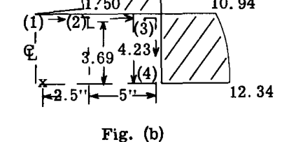

Fig. (b)

パネル(A)上の剪断流 $q$ は $4.20$ から $7.20$ まで変化し、平均 $q = (4.2 + 7.2)/2 = 5.7$ です。したがって、平均剪断応力は $5.7 / 0.035 = 163$ psi です。これはねじり剪断流と同じ方向であるため、加算されます。

この例題では、パネルは単純支持と仮定されており、これは保守的です。Fig. C5.6を参照すると、パネルはねじり抵抗を持つゼット型補強材にリベット留めされているため、 $k_C$ はより高く仮定でき、したがってパネルはその境界で自由に回転することはできません。

$R_C + R_S^2 = 0.905 + 0.246^2 = 0.966$ 。結果は1.0未満であるため、パネルは座屈しません。

パネル(B)は、パネルの中央でゼロであり、端部で1.5 lb./in.まで一様に増加し、中心線から反対方向に流れる小さな剪断流を運びます。したがって、横剪断は無視できる影響しかありません。したがって、 $R_S = 854/2760 = 0.309$ です。

$R_C + R_S^2 = 0.905 + 0.309^2 = 1.00$ 。すなわち、パネル(B)は、溶液中の仮定の下で座屈の瀬戸際にあります。

## C5.14 問題

1. 板パネルのサイズは $3" \times 9" \times 0.051"$ である。すべての辺が単純支持されていると仮定する。圧縮荷重が $3"$ の辺に対して垂直に加えられる場合の座屈荷重を求めよ。3つの異なる材料、すなわち(1) アルミニウム合金 7075-T6、(2) マグネシウム HK31A、(3) チタン Ti-8Mn について行え。
2. 問題(1)において、すべての端部が固定されている場合、座屈荷重はいくらになるか。
3. 問題(1)において、 $9"$ の辺が固定され、 $3"$ の辺が単純支持されている場合、座屈荷重はいくらになるか。
4. 板パネル $5" \times 12.5" \times 0.051"$ は、すべての辺が単純支持されている。パネルは複合圧縮および剪断荷重を受けており、これらは以下の応力を発生させる：

$f_c = 2400$ psi、 $5"$ の辺に対して垂直に作用。

$f_s = 2800$ psi。材料が 2024-T3 アルミニウム合金である場合、与えられた荷重系の下で板は座屈するか。安全余裕はいくらか。

5. 問題(4)において、材料が合金鋼 $F_{tu} = 95,000$ psi に変更された場合、安全余裕はいくらになるか。板が $F_{tu} = 180,000$ psi に熱処理された場合、M.S. はいくらになるか。
6. $3" \times 12" \times 0.040"$ の板パネルが、以下の複合応力を受けている。 $f_c = 3000$ 、 $f_b = 10000$ 、 $f_s = 8000$ 。 $f_c$ および $f_b$ 応力は $3"$ の辺に対して垂直である。辺が単純支持されている場合、7075-T6アルミニウム合金製であればパネルは座屈するか。M.S. はいくらか。

材料が チタン Ti-8Mn に変更された場合、M.S. はいくらになるか。

## 参考文献

1. NACA Tech. Note 3781, 1957.
2. ANC-5 Amendment 2. Aug. 1946.
3. NACA ARR. No. L6A05
4. NACA ARR. No. 3K13
5. ANC-5 Revision of 1942

## 理論に関する一般参考文献

6. NACA Tech. Note 3781.
7. “Introduction to Structural Stability Theory”. By Gerard. Book published by McGraw-Hill.
8. “Theory of Elastic Stability”, by Timoshenko, McGraw-Hill Co.
9. “A Unified Theory of Plastic Buckling of Columns and Plates”, NACA Report 898. By Stowell.
10. “Plastic Buckling of Simply Supported Compressed Plates”, NACA T.N. 1817. By Pride & Heimerl.
11. “Buckling of Metal Structures” by Bleich. McGraw-Hill Co.